# Inteligencia Artificial Generativa (AI Gen)

De la palabra al transformer

Autor: Paulo Veiga, Claudio Righetti, Marco Sorondo (Universidad Austral)  
Última modificación: 2026-09-23

01Un modelo por cada tarea 02Predecir lo que sigue 03Palabras como vectores 04De las RNN a la atención 05El transformer completo

01

Un modelo por cada tarea

Un modelo por cada tarea

## Lo que ya vieron sobre tipos de problema

Repaso de una lámina. En la clase 4 el catálogo de tareas se organizó por la forma de la salida; acá interesa una sola distinción, y es la última.

### Predecir un valor

Un número, una clase entre N, varias etiquetas, un conteo. Es lo que la clase 4 recorrió tarea por tarea, con su capa de salida y su loss para cada una.

### Agrupar sin etiquetas

Descubrir qué datos se parecen cuando nadie definió las categorías de antemano.

### Generar

Producir algo nuevo que se parezca a los datos de entrenamiento sin copiarlos. **La cantidad de salidas posibles no tiene tope**, y esa es la diferencia que importa.

Las dos primeras eligen dentro de un conjunto conocido. La tercera no tiene conjunto. Un modelo de lenguaje vive en la tercera, y el resto de la clase explica cómo se las arregla para que sea tratable.

Un modelo por cada tarea

## Los mismos problemas, con texto

**Cada formulación clásica tiene su equivalente cuando la entrada es texto. Cambia el tipo de dato, no la forma del problema.**

- **Predicción y generación son la misma operación en distinta posición.**: Las dos completan un hueco con el token más probable; la única diferencia es dónde está el hueco.
- **Todas necesitan lo mismo primero**: alguna forma de convertir texto en algo que un modelo pueda operar. Eso es tokenizar y embeber, y es la sección *Tokens y embeddings*.

FormulaciónQué resuelveEjemplo con texto

ClasificaciónAsignar una categoría¿Este comentario es positivo o negativo?

Clasificación multiclaseElegir entre varias categorías¿En qué idioma está escrito?

ClusteringAgrupar datos similaresAgrupar incidentes por causa raíz

PredicciónCompletar información faltante`The ___ is on the mat` → `cat`

GeneraciónCrear datos nuevos`The cat is on the ___` → `mat`

Un modelo por cada tarea

## Hay más texto del que se puede leer

**Procesamiento del lenguaje natural (NLP) es el campo que se ocupa de resolver estas tareas de forma automática, sobre volúmenes de texto que nadie va a leer entero.**

### De dónde sale el texto

Tickets de soporte, mensajes de commit, logs de aplicación, documentación técnica, hilos de incidentes, correos, foros y reseñas de usuarios.

### Qué se le pide

Analizar miles de reportes de usuarios sobre una misma versión; clasificar tickets por área; detectar el idioma de un documento; responder preguntas sobre un texto largo; resumir un informe de treinta páginas en un párrafo.

El volumen es lo que convierte estas tareas en un problema de ingeniería. Cualquiera de ellas la resuelve una persona sobre diez documentos; ninguna se resuelve así sobre diez mil.

Un modelo por cada tarea

## Veinticinco tareas de NLP

**Las cinco familias, aterrizadas. Cada columna es una formulación de la lámina anterior y cada celda una tarea que alguien resuelve hoy en producción.**

ClasificaciónClasificación multiclaseClusteringPredicciónGeneración

Detección de spam (spam / no spam)Detección de idioma (español, inglés, francés…)Agrupar noticias por temaAutocompletar en un buscadorResumen automático de textos

Análisis de sentimiento (positivo / negativo)Clasificación de intención (comprar, preguntar, quejarse…)Agrupar reseñas similares de productosPredecir la siguiente palabra de una oraciónTraducción automática

Detección de discurso de odio (sí / no)Etiquetado gramatical (sustantivo, verbo, adjetivo…)Segmentar usuarios por estilo de escrituraCompletar huecos en el texto (masked LM)Generación de respuestas en chatbots

Detección de noticias falsas (real / falsa)Clasificación de emociones (alegría, tristeza, enojo, miedo…)Descubrir tópicos en un corpusPredecir la puntuación de una reseñaGeneración de código a partir de texto

Detección de paráfrasis (sí / no)Clasificación de tickets de soporte (facturación, técnico, ventas…)Agrupar documentos legales por áreaPredecir palabras faltantes en un OCR dañadoParafraseo automático de oraciones

Un modelo por cada tarea

## Un modelo por tarea

**Antes de los modelos fundacionales, cada tarea de la matriz anterior necesitaba su propio conjunto de datos etiquetado y su propio modelo entrenado desde cero.**

- **Recolectar, etiquetar, entrenar**: eran los tres trabajos, y el segundo no se automatizaba: alguien tenía que marcar a mano qué era positivo y qué negativo.

[figure not shown]

01Un modelo por cada tarea 02Predecir lo que sigue 03Palabras como vectores 04De las RNN a la atención 05El transformer completo

02

Predecir lo que sigue

Predecir lo que sigue

## Predecir la palabra que sigue

**El problema tiene tres entradas: un vocabulario V, un corpus de texto T y una frase incompleta P. La salida es el token más probable a continuación de P.**

- **Por qué esto escala y lo anterior no.**: El texto crudo trae la respuesta adentro. Todo lo escrito en internet es un conjunto de entrenamiento ya etiquetado para esta tarea.

[figure not shown]

Predecir lo que sigue

## La salida es un vector, no una palabra

**El modelo devuelve un número por cada token del vocabulario: la probabilidad de que ese token sea el siguiente. El vector tiene longitud |V|.**

### Una posición por token del vocabulario.

El valor de cada posición es la probabilidad de ese token, y las |V| posiciones suman uno.

### Elegir viene después.

Quedarse con el máximo es una decisión aparte, y no es la única. Muestrear con algo de aleatoriedad es la otra, y es lo que controla la temperatura.

[figure not shown]

Predecir lo que sigue

## Los modelos no leen letras

**Un token es la unidad mínima que el modelo procesa: una palabra entera, un pedazo de palabra o un signo de puntuación. Tokenizar es el primer paso de cualquier tarea de NLP.**

- **Vocabularios más chicos**: No hace falta una entrada por cada palabra del idioma, y las palabras nuevas se arman con piezas.

[figure not shown]

Predecir lo que sigue

## Catorce tokens y cinco frases

**El mismo problema, con números chicos: un vocabulario de 14 tokens, un corpus de 5 frases y una frase incompleta.**

### V

`{ "a", "to", "on", "the", "sat", "cat", "dog", "bed", "ran", "mat", " ", "<fin>", ".", "," }` — 14 tokens.

### T

`"the cat sat on mat"` · `"a dog ran to bed"` · `"the dog sat on bed"` · `"a cat ran to mat"` · `"the cat ran to dog"` — 5 frases.

### P

`"the dog sat on"`. La única frase del corpus que empieza así continúa con `"bed"`, así que ésa es la respuesta correcta.

### El vector objetivo es todo ceros y un uno

en la posición de `bed`. Entrenar es acercar la salida del modelo a ese vector.

Predecir lo que sigue

## Aprender es ajustar parámetros

**Un modelo por dentro es un conjunto de números ajustables. Entrenar es buscar los valores que hacen que la salida se parezca al vector objetivo.**

### Parámetros

Los números internos del modelo, los que el deck llama "clavijas". Empiezan en valores arbitrarios y son lo único que el entrenamiento modifica.

### Loss (pérdida)

Un número que mide qué tan lejos quedó la salida del modelo del vector objetivo. Cuanto más chico, mejor predijo.

### Optimización

El procedimiento que ajusta los parámetros para que la loss baje. Termina quedándose con los valores que dan la loss más chica.

El método no depende de la tarea. Cambia qué es la respuesta correcta (el token siguiente, la categoría, el número) y el resto del procedimiento es el mismo para cualquiera de las tareas de NLP ya vistas.

01Un modelo por cada tarea 02Predecir lo que sigue 03Palabras como vectores 04De las RNN a la atención 05El transformer completo

03

Palabras como vectores

Palabras como vectores

## Tres formas de volver texto en números

**El vocabulario V es el conjunto de tokens que el modelo conoce, y por eso predice un vector de tamaño |V|. Pero un token es texto, y los parámetros son números: hace falta una representación numérica.**

### Bag of words / TF-IDF

Contar apariciones de cada palabra. Ignora el orden y el significado.

### One-hot encoding

Un vector de largo |V| con un solo uno, en la posición del token. Distingue tokens, pero todos quedan a la misma distancia entre sí.

### Embeddings

Vectores densos de unos cientos de dimensiones, donde los tokens de significado parecido caen cerca. Es lo que usan los modelos modernos.

[figure not shown]

Palabras como vectores

## De token a vector

**Un embedding de texto es un vector que codifica el significado de un token. Cada token del vocabulario tiene el suyo, y ese vector es lo que entra al modelo.**

### El circuito completo

Palabra, fila de números, punto en el espacio. Las tres cosas son la misma, escritas de tres maneras.

### La dimensión no es interpretable de a una.

Ningún eje del espacio significa algo por separado; lo único que se lee es la posición relativa entre puntos.

[figure not shown]

Palabras como vectores

## El espacio de embeddings

**Los tokens de significado parecido caen cerca. Esa cercanía es lo único que el espacio codifica, y es lo que permite comparar dos textos sin compararlos palabra por palabra.**

### Los vecindarios son campos de significado.

Realeza en una zona, frutas en otra, sin que nadie haya escrito esas categorías: salen de con qué palabras aparece cada una en el corpus.

### La cercanía se mide, no se lee.

En dos dimensiones se ve; en las varias centenas reales del espacio, se calcula.

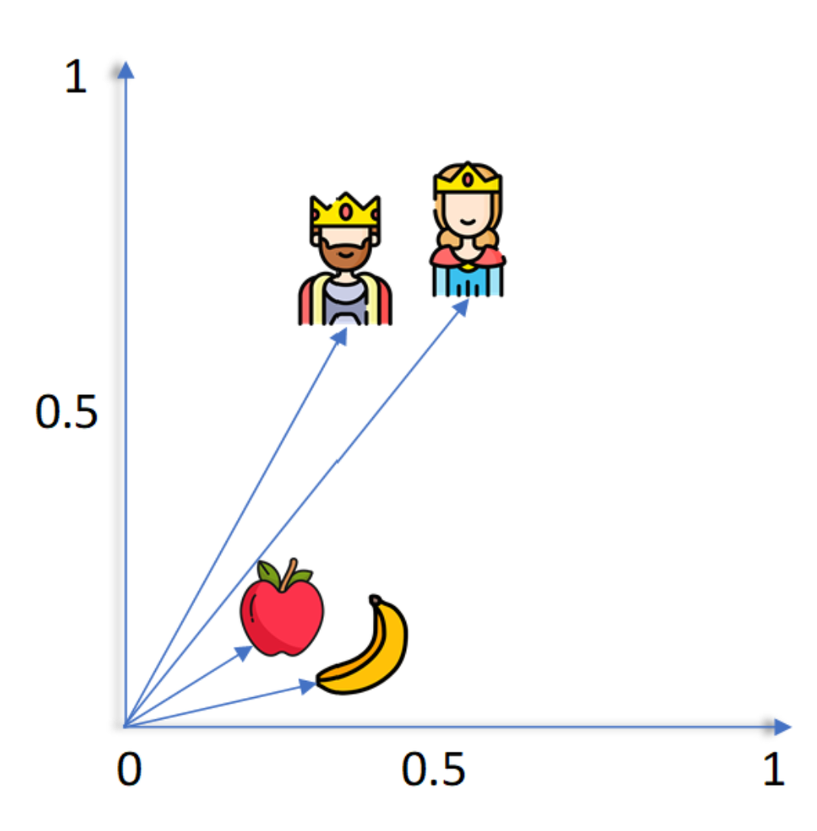

Palabras como vectores

## Las relaciones también son vectores

**El espacio no sólo agrupa: también guarda relaciones. El desplazamiento que lleva de "man" a "woman" es el mismo que lleva de "king" a "queen".**

### La regularidad no es un accidente del ejemplo de género.

Se repite con tiempo verbal (walking → walked, swimming → swam) y con país y capital (Italy → Rome, Japan → Tokyo).

### De ahí sale la aritmética de analogías

que se cita seguido como `rey − hombre + mujer ≈ reina`.

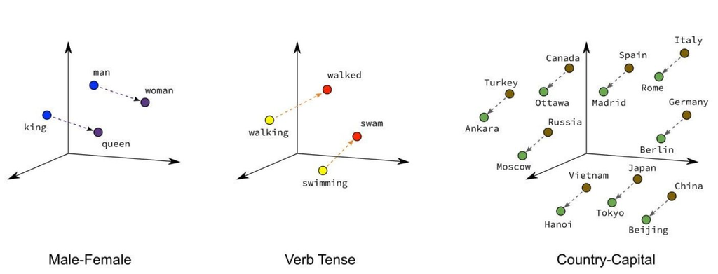

Palabras como vectores

## Word2Vec aprende de la compañía

**Word2Vec es un método para aprender los vectores de embedding a partir de un corpus, sin que nadie los diseñe a mano. Parte de que una palabra queda definida por las palabras que la rodean.**

### Qué produce

Un vector por palabra del vocabulario, aprendido de las coocurrencias del corpus. Vectores, no texto.

### Qué no es

Un modelo de lenguaje. Word2Vec no genera palabras; produce las representaciones que después usa un modelo que sí genera.

### Qué cuesta

Menos de un día para aprender vectores de calidad sobre un corpus de 1.600 millones de palabras, según el paper original. Esa es la mitad interesante del resultado: gana precisión y baja el costo a la vez.

Cada palabra recibe un vector y sólo uno, sin importar la frase en la que aparezca. "Banco" tiene el mismo vector en un río que en una plaza. Resolver eso es lo que motiva las representaciones contextuales y, después, la atención.

01Un modelo por cada tarea 02Predecir lo que sigue 03Palabras como vectores 04De las RNN a la atención 05El transformer completo

04

De las RNN a la atención

De las RNN a la atención

## Lo que ya vieron sobre redes

**Todo esto se dio en las clases 3 y 4. Va como repaso de una lámina, porque el resto de la clase se apoya en ello.**

### La neurona

Una combinación lineal de las entradas más un sesgo, seguida de una no linealidad. Clase 3.

### La profundidad

Apilar capas es lo que permite representar funciones que una sola capa no puede. Clase 3.

### El entrenamiento

Calcular el error, ver en qué dirección baja, mover los pesos un paso, repetir. El tamaño del paso es el learning rate. Clases 3 y 4.

### La retropropagación

El error vuelve por cada conexión, con la regla de la cadena, y a cada peso le toca su parte. Clase 3.

De las RNN a la atención

## Promediar una frase pierde el orden

**Un perceptrón necesita un vector de tamaño fijo, y una frase son varios vectores. La forma directa de resolverlo es promediarlos, y esa forma tiene un costo.**

- **Ésta es la limitación que arrastra Word2Vec al pasar de palabra a frase.**: El método da un vector por palabra; el promedio es una agregación que se aplica encima, no parte del método.

[figure not shown]

De las RNN a la atención

## Una red sin memoria

**Una red común procesa cada entrada de forma independiente: dado el mismo vector, produce siempre la misma salida. Una red recurrente recibe además el estado que dejó el paso anterior, y con eso arrastra lo que ya procesó.**

### El caso concreto

Al procesar `"The cat is on the _"`, una red común da siempre la misma salida para `"cat"`, venga de donde venga. Una recurrente guarda lo que produjo con `"The"` y lo usa para procesar `"cat"`.

### Lo único que cambia es una conexión.

Las dos columnas tienen los mismos pasos, la misma red y las mismas palabras. La diferencia está en que a la derecha el paso 2 recibe también el estado del paso 1, y eso alcanza para que haya memoria.

[figure not shown]

De las RNN a la atención

## La red desenrollada en el tiempo

**Desenrollar la red es dibujar una copia por cada token de la frase. Las copias comparten los mismos pesos, y lo único que viaja de una a la otra es el estado.**

- **Un solo juego de pesos, cualquier largo de frase.**: Es lo que permite entrenar con frases de cinco palabras y aplicar el modelo a una de cincuenta.

[figure not shown]

De las RNN a la atención

## Todo el pasado en un vector

**El estado tiene un tamaño fijo y no crece con la frase. Cuanto más larga la entrada, más comprimido queda cada token, y el primero que entró es el primero que se diluye.**

- **El cuello de botella está en la arquitectura, no en el entrenamiento.**: El modelo encoder-decoder de Cho y otros (2014) lo describe de frente: una RNN codifica la secuencia entera en una representación vectorial de longitud fija, y la otra la decodifica.

[figure not shown]

De las RNN a la atención

## LSTM, GRU y ELMo

**Tres trabajos que empujaron la línea recurrente antes de que la atención la reemplazara.**

### LSTM

Una celda recurrente con compuertas que deciden qué guardar y qué descartar del estado en cada paso. Ataca la dilución que muestra la lámina anterior.

### GRU

La celda con compuertas que introduce el trabajo de Cho y otros (2014), dentro del modelo encoder-decoder. Se usa como alternativa más chica a la LSTM.

### ELMo

Representaciones de palabra profundamente contextualizadas: el vector de una palabra cambia según la oración en la que aparece. Sale de las capas internas de un modelo de lenguaje bidireccional preentrenado, y su paper nombra la polisemia como el problema que viene a resolver.

ELMo es lo que arregla el límite de Word2Vec: ahí "banco" tiene un solo vector; con representaciones contextuales tiene uno por contexto.

De las RNN a la atención

## Cuando "it" queda lejos

**En `"The animal didn't cross the street because it was too tired"`, resolver a qué se refiere `it` obliga a llegar hasta `animal`. Con recurrencia esa información recorre seis estados intermedios; con atención, uno solo.**

[figure not shown]

De las RNN a la atención

## Cada token mira a todos

**La atención le da a cada token un peso contra todos los demás tokens de la secuencia, y con esos pesos arma su propia lectura de la frase.**

- **Qué captura**: Dependencias largas entre palabras separadas, relaciones sintácticas de sujeto, verbo y objeto, y relaciones semánticas de contexto.

[figure not shown]

De las RNN a la atención

## Qué se gana al soltar la recurrencia

**El Transformer prescinde por completo de recurrencia y de convoluciones, y se apoya sólo en mecanismos de atención. El resultado del paper original es doble: mejor calidad y menos tiempo de entrenamiento a la vez.**

### Paralelización

Sin dependencia secuencial, la secuencia entera se procesa de una. Es la consecuencia directa de sacar la recurrencia, y lo que permite aprovechar una GPU de punta a punta.

### Calidad medida

28,4 BLEU en la tarea de traducción inglés a alemán de WMT 2014, más de 2 puntos BLEU por encima de los mejores resultados previos, incluidos los ensambles. Y 41,8 BLEU en inglés a francés, estado del arte para modelo único.

### Costo medido

Ese resultado de inglés a francés salió de 3,5 días de entrenamiento sobre ocho GPU, que los autores describen como una fracción pequeña del costo de los mejores modelos de la literatura.

La arquitectura no quedó atada a la traducción: el mismo paper la aplica a análisis sintáctico de constituyentes en inglés, con datos abundantes y con datos limitados.

01Un modelo por cada tarea 02Predecir lo que sigue 03Palabras como vectores 04De las RNN a la atención 05El transformer completo

05

El transformer completo

El transformer completo

## La arquitectura de 2017

**El Transformer es la arquitectura que reemplazó a las RNN en 2017. Procesa la secuencia entera de una vez, en paralelo, apilando bloques de atención.**

### Dos columnas, dos trabajos.

La izquierda codifica la entrada; la derecha genera la salida token a token y consulta a la izquierda por el camino.

### El softmax de arriba es la distribución sobre el vocabulario.

El "Output Probabilities" del tope de la figura es literalmente ese vector de tamaño |V| con el que se formuló el modelado de lenguaje.

Figura 1 de Vaswani, Shazeer, Parmar, Uszkoreit, Jones, Gomez, Kaiser y Polosukhin, *Attention Is All You Need*, arXiv:1706.03762 (2017).

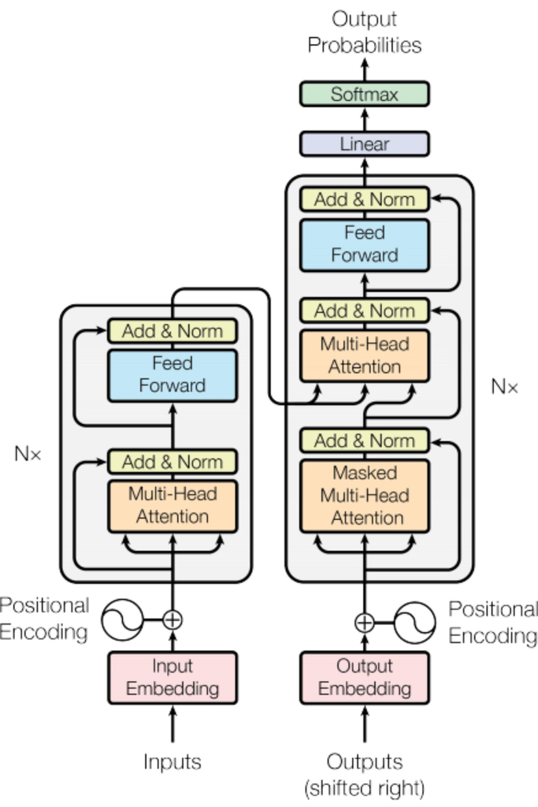

El transformer completo

## Tres generaciones de representación

**El recorrido de la clase, en una tabla: representaciones estáticas, después secuenciales, después contextuales con atención.**

Idea principalLo que aportóLo que no resuelve

**Word2Vec**Aprende embeddings del contexto en el que aparecen las palabrasRepresentaciones semánticas aprendidas sin supervisión; las palabras parecidas quedan cercaUn solo vector por palabra, sin importar el contexto. No modela el orden ni las secuencias

**RNN (LSTM, GRU)**Procesan el texto secuencialmente con un estado interno que hace de memoriaModelan secuencias y dependencias temporales; habilitaron traducción y generaciónProcesamiento secuencial, no paralelizable. Pierden información en secuencias largas

**Transformers**Atención para que cada token mire a todos los demás, en paraleloDependencias largas sin degradación y entrenamiento paralelo. Base de todos los LLM actualesEnormes cantidades de datos y cómputo. La atención crece cuadráticamente con la longitud

El transformer completo

## El ciclo de un LLM, token a token

**Cada palabra que aparece en pantalla es una vuelta entera de este ciclo. El modelo escribe un token, se vuelve a leer completo y escribe el siguiente.**

- **Temperatura**: El parámetro que decide cuánta aleatoriedad hay en el paso de elegir. Con temperatura cero, siempre el token más probable.

[figure not shown]

El transformer completo

## El mismo problema, a otra escala

**Es la misma formulación de modelado de lenguaje, con los mismos tres ingredientes y otro orden de magnitud.**

- **El concepto no cambia**: predecir el token siguiente. Lo que cambia es el tamaño del vocabulario, la cantidad de datos y la del modelo.

El ejemplo de jugueteUn LLM de hoy

**Vocabulario V**14 tokensdel orden de 100.000 tokens, sub-palabras de varios idiomas

**Corpus T**5 frasestexto de internet, libros, código y papers

**Parámetros**pocosdel orden de cientos de miles de millones

**Frase P**`"the dog sat on"`cualquier texto, de cualquier largo

El transformer completo

## Casi cualquier tarea es generación

**Un modelo que comprende texto y genera palabras permite reescribir casi cualquier tarea de NLP como una instrucción en texto.**

### Sentimiento

`"¿Este comentario es positivo o negativo?"` → el modelo genera `"positivo"`.

### Traducción

`"Traducí: the cat is on the mat"` → el modelo genera `"el gato está sobre la alfombra"`.

### Resumen

`"Resumí este texto: […]"` → el modelo genera el resumen.

### La cadena completa

problema → prompt (instrucción en texto) → el modelo genera la solución.

Con el enfoque tradicional, esas tres tareas necesitaban tres conjuntos etiquetados y tres modelos entrenados por separado. Acá son tres frases contra el mismo modelo.

El transformer completo

## Entrenamiento e inferencia

**Dos fases distintas, con costos, responsables y momentos distintos. Confundirlas es el malentendido más común sobre estos modelos.**

- **Una conversación no entrena al modelo.**: Los parámetros ya están fijos; lo que ocurre en el chat es inferencia.
- **Por eso son pocas las organizaciones que entrenan.**: Entrenar un modelo grande pide un corpus de escala web y miles de GPU durante semanas.

EntrenamientoInferencia

**Qué pasa**Aprende ajustando parámetrosUsa parámetros ya aprendidos

**Cuándo**Antes de que el modelo esté disponibleCada vez que alguien pregunta

**Quién**OpenAI, Anthropic, Meta y unos pocos másCualquiera que use el modelo

**Costo**Millones de dólares, semanasFracción de segundo por respuesta

**Parámetros**Se modifican constantementeEstán congelados

El transformer completo

## Lo que queda de la clase

### Un modelo de lenguaje hace una sola cosa.

Predice el token siguiente y devuelve una distribución sobre el vocabulario entero. Todo lo demás de la clase, tokens, embeddings, capas, gradientes y atención, existe para que esa predicción use el contexto.

### La etiqueta gratis es lo que cambió la escala.

Mientras cada tarea necesitaba su propio conjunto etiquetado a mano, el costo crecía tarea por tarea. El texto crudo trae la respuesta correcta adentro, y eso convirtió a internet en conjunto de entrenamiento.

### El cuello de botella de las RNN era estructural.

Comprimir la frase entera en un vector de tamaño fijo diluye lo primero que entró, y ningún entrenamiento arregla eso. La atención lo elimina dejando que cada token consulte a todos los demás en un solo paso.

### Un LLM de hoy es el ejemplo de catorce tokens con otro tamaño.

Cambian el vocabulario, los datos y la cantidad de parámetros. La cuenta es la misma.

### Verificá las cifras antes de repetirlas.

Este mismo deck citaba tres papers sin nombrarlos y usaba "billones" en un sentido ambiguo entre 10⁹ y 10¹². Pasa en el material de todos, incluido el nuestro.

Girá el teléfono para ver las diapositivas